# DA 5030 Practice Problem 1

# Question 1:

**Comment:** As the question 1 requested, RStudio was downloaded to execute the code and to organize the output into a readable report. The codes are written in .rmd file and will be saved in .html for its R Markdown version.

# Question 2:

```r
customer_df = read.csv("/Users/sanikakalvikatte/Downloads/customertxndata.csv", header = FALSE)
customer_df
```

| V1 | V2 | V3 | V4 | V5 |
| --- | --- | --- | --- | --- |
| 7 | 0 | Android | Male | 0.0000 |
| 20 | 1 | iOS | NA | 576.8668 |
| 22 | 1 | iOS | Female | 850.0000 |
| 24 | 2 | iOS | Female | 1050.0000 |
| 1 | 0 | Android | Male | 0.0000 |
| 13 | 1 | Android | Male | 460.0000 |
| 23 | 2 | iOS | Male | 1850.0000 |
| 14 | 1 | Android | Male | 480.0000 |
| 11 | 1 | Android | Male | 110.0000 |
| 24 | 2 | iOS | Male | 1950.0000 |

[output cut: 9990 more lines]

**Comment:** The provided data set customertxndata.csv has been downloaded and uploaded in the RStudion with the help of read.csv() function. The first glance at the data provided shows that there is no available header in the data, thus, header = FALSE has been used in the code. Moreover, we need header to understand the numbers and its units for data analysis. Thus colnames() function was used to rename the suggested column names with respect to the index number of the column.

```r
colnames(customer_df)[1] <- "customer_visits"
colnames(customer_df)[2] <- "customer_transactions"
colnames(customer_df)[3] <- "customer_operation_system"
colnames(customer_df)[4] <- "customer_gender"
colnames(customer_df)[5] <- "revenue"
customer_df
```

| customer_visits | customer_transactions | customer_operation_system | customer_gender | revenue |
| --- | --- | --- | --- | --- |
| 7 | 0 | Android | Male | 0.0000 |
| 20 | 1 | iOS | NA | 576.8668 |
| 22 | 1 | iOS | Female | 850.0000 |
| 24 | 2 | iOS | Female | 1050.0000 |
| 1 | 0 | Android | Male | 0.0000 |
| 13 | 1 | Android | Male | 460.0000 |
| 23 | 2 | iOS | Male | 1850.0000 |
| 14 | 1 | Android | Male | 480.0000 |
| 11 | 1 | Android | Male | 110.0000 |
| 24 | 2 | iOS | Male | 1950.0000 |

[output cut: 9990 more lines]

# Question 3:

```r
library(dplyr)
summary(customer_df)
```

```
##  customer_visits customer_transactions customer_operation_system
##  Min.   : 0.00   Min.   :0.000         Length:22800
##  1st Qu.: 6.00   1st Qu.:1.000         Class :character
##  Median :12.00   Median :1.000         Mode  :character
##  Mean   :12.49   Mean   :0.993
##  3rd Qu.:19.00   3rd Qu.:1.000
##  Max.   :25.00   Max.   :2.000
##                  NA's   :1800
##  customer_gender       revenue
##  Length:22800       Min.   :   0.0
##  Class :character   1st Qu.: 170.0
##  Mode  :character   Median : 344.7
##                     Mean   : 454.9
##                     3rd Qu.: 576.9
##                     Max.   :2000.0
##
```

```r
sd(customer_df$revenue)
```

```
## [1] 425.9884
```

```r
total_rev <- customer_df %>% mutate(cum_sales = cumsum(revenue))
max(total_rev$cum_sales)
```

```
## [1] 10372524
```

```r
gender_ratio <-
customer_df %>%
   group_by(customer_gender) %>%
   summarise(gender_count = n())

na.omit(gender_ratio)
```

| customer_gender | gender_count |
| --- | --- |
| Female | 2670 |
| Male | 14730 |

**Comment:** The summary() provides a wide glimpse at the values and the volume of data we are dealing with, this is useful for detailed data analysis. The total transaction amount (revenue): 10372524, mean number of visits = 12.49, median revenue = 344.7, standard deviation of revenue = 425.9884, most common gender = Male(14730). Excluding any cases where there is a missing value. The function na.omit() was used for filtering missing values.

# Question 4:

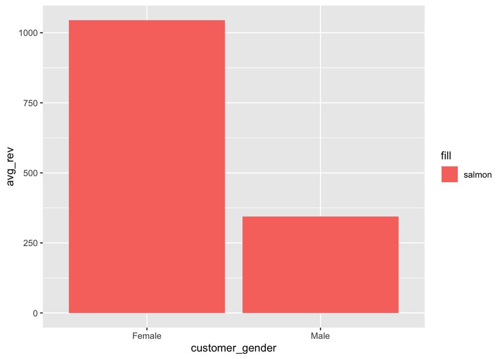

```r
library(ggplot2)
library(tidyverse)
avg_rev <- customer_df %>%
  drop_na(customer_gender) %>%
  group_by(customer_gender) %>%
  summarise(avg_rev = mean(revenue))


avg_rev %>%
  ggplot(mapping = aes(x=customer_gender, y = avg_rev)) + geom_bar(stat = "identity",aes(fill = 'salmon'))
```

# Question 5

```r
# Pearson correlation between 2 variables
cor(customer_df$customer_visits, customer_df$revenue, method = "pearson")
```

```
## [1] 0.7388448
```

**Comment:** The Pearson Moment of Correlation shows the amount of relationship the two variables have with each other. The correlation closer to +1 denotes higher linear(increasing) relationship, -1 denotes negative(declining) relationship and 0 denotes no relationship. There seems to a positive increasing correlation between the customers visit and the revenue. A correlation as higher as 0.73, denotes that the variable are highly correlated and linear to each other.

# Question 6

```r
df_na <- is.na(customer_df)

colSums(df_na)
```

```
##           customer_visits     customer_transactions customer_operation_system
##                         0                      1800                         0
##           customer_gender                   revenue
##                      5400                         0
```

```r
which(colSums(df_na)>0)
```

```
## customer_transactions       customer_gender
##                     2                     4
```

```r
names(which(colSums(df_na)>0))
```

```
## [1] "customer_transactions" "customer_gender"
```

**Comment:** The fields customer_transactions and customer_gender have NA in there data, which means they have missing data. These values could be recognized by the help of is.na() function in r. This gives us values in True or False, as per the NA value exists. After that I have taken a sum of all the NAs in the column and filter only those who have NAs more than 0. Thus returning the fields with missing values. The fields could be imputed in various ways, for customer_transactions an average would be better substitution, if we can figure out the mean transaction value and simply substitute the average value in the missing fields could work. Similar, in the case of higher outlier count median od the transaction value would work better. For more precise information to use as imputation data, a regression model can be built for predicting the fit based on various factor for that individual, for example: zip code, number of previous transactions, years of enrollment, etc. For the field customer_gender, a decision tree could be used, for example male customers buy certain items much more than a female customer would usually do. Strong gender based first name, can be a part of this decision tree.

# Question 7

```r
mean(customer_df$customer_transactions, na.rm=TRUE)
```

```
## [1] 0.993
```

```r
Mode <- function(x) {
  ux <- na.omit(unique(x) )
 tab <- tabulate(match(x, ux)); ux[tab == max(tab) ]
}

Mode(customer_df$customer_gender)
```

```
## [1] "Male"
```

**Comment:** To find out suitable imputation value, here mean of customer_transactions was used. The mean value is around 0.99 ~ 1 (rounded to the nearest whole number). And for customer_gender mode() has been used. The mode denotes that there are consecutive Male gender in the data frame thus Male would be a suitable imputation value.

```r
library("dplyr")
library("tidyr")

customer_df["customer_transactions"][is.na(customer_df["customer_transactions"])] <- 1

customer_df <- customer_df %>%
  mutate_at(c('customer_gender'), ~replace_na(.,"Male"))
```

**Comment:** There are two different type of values that are being replaced, 1 is numeric and Male is string, thus the suitable code for imputation has been used.

```r
df_na <- is.na(customer_df)

colSums(df_na)
```

```
##           customer_visits     customer_transactions customer_operation_system
##                         0                         0                         0
##           customer_gender                   revenue
##                         0                         0
```

**Comment:** The above code is just for validation purpose, to see if there are any NA values still available in the data frame, since, the question aims to impute all the missing values.

# Question 8

```r
nrow<-nrow(customer_df)
training_set<-customer_df[seq(1,nrow,by=2),] #select only odds rows
validation_set<-customer_df[seq(2,nrow,by=2),] #select only even rows
training_set
```

|  | customer_visits | customer_transactions | customer_operation_system | customer_gender | revenue |
| --- | --- | --- | --- | --- | --- |
| 1 | 7 | 0 | Android | Male | 0.0000 |
| 3 | 22 | 1 | iOS | Female | 850.0000 |
| 5 | 1 | 0 | Android | Male | 0.0000 |
| 7 | 23 | 2 | iOS | Male | 1850.0000 |
| 9 | 11 | 1 | Android | Male | 110.0000 |
| 11 | 17 | 1 | Android | Male | 225.0000 |
| 13 | 2 | 0 | Android | Male | 0.0000 |
| 15 | 24 | 2 | iOS | Male | 1850.0000 |
| 17 | 18 | 2 | Android | Male | 990.3062 |
| 19 | 25 | 2 | iOS | Male | 1950.0000 |

[output cut: 9990 more lines]

```r
validation_set
```

|  | customer_visits | customer_transactions | customer_operation_system | customer_gender | revenue |
| --- | --- | --- | --- | --- | --- |
| 2 | 20 | 1 | iOS | Male | 576.8668 |
| 4 | 24 | 2 | iOS | Female | 1050.0000 |
| 6 | 13 | 1 | Android | Male | 460.0000 |
| 8 | 14 | 1 | Android | Male | 480.0000 |
| 10 | 24 | 2 | iOS | Male | 1950.0000 |
| 12 | 14 | 1 | Android | Male | 344.6516 |
| 14 | 8 | 1 | Android | Male | 344.6516 |
| 16 | 23 | 2 | iOS | Female | 1300.0000 |
| 18 | 16 | 1 | Android | Male | 405.2441 |
| 20 | 17 | 1 | Android | Male | 550.0000 |

[output cut: 9990 more lines]

**Comment:** As suggested in the question the data has been seggregated into two parts as per the row number, row 1, 3, 5, 7, etc. are training data while rows 2, 4, 6, etc. are validation data. The nrow() function was used to get the accurate row number for seggrigation of the data.

# Question 9:

```r
mean(training_set$revenue, na.rm=TRUE)
```

```
## [1] 449.6105
```

```r
mean(validation_set$revenue, na.rm=TRUE)
```

```
## [1] 460.26
```

```r
library(dplyr)

training_set %>%
  count(customer_gender)
```

| customer_gender | n |
| --- | --- |
| Female | 1342 |
| Male | 10058 |

```r
validation_set %>%
  count(customer_gender)
```

| customer_gender | n |
| --- | --- |
| Female | 1328 |
| Male | 10072 |

# Question 10:

```r
## set the seed to make your partition reproducible
set.seed(77654)

training_size <- sample.int(n = nrow(customer_df), size = floor(.60*nrow(customer_df)), replace = F)
testing_size <- sample.int(n = nrow(customer_df), size = floor(.20*nrow(customer_df)), replace = F)
validation_size <- sample.int(n = nrow(customer_df), size = floor(.20*nrow(customer_df)), replace = F)

train <- customer_df[training_size, ]
test  <- customer_df[-testing_size, ]
validation <- customer_df[-validation_size, ]
```